# Team

Our work on PHES-EF is led by an international collaborative group committed to transparency and rigour in the evaluation of public health environmental surveillance. Our team brings together expertise from diverse regions, disciplines, and actor and end-user perspectives.

11

Executive group members

5/7

World Bank regions

5/5

Discipline subgroups

3

Study working group

## Executive group

The executive group oversees and supports the development of PHES-EF. Co-chaired by Doug Manuel and David Buckeridge, it brings together members from five World Bank regions and all five of the study’s discipline subgroups: public health, infectious disease and epidemiology; environmental and physical sciences; mathematical sciences; social sciences; and communication, knowledge translation and exchange.

Members contribute by:

- Reviewing the candidate evaluation items for their organization, completeness, gaps and redundancy
- Advising the study working group in their areas of expertise
- Connecting the study with related projects and networks
- Helping identify e-Delphi panellists and promoting the survey among their professional contacts
- Taking part in the consensus meeting to agree on the final framework
- Guiding dissemination and promoting adoption of the framework among actors and end-users

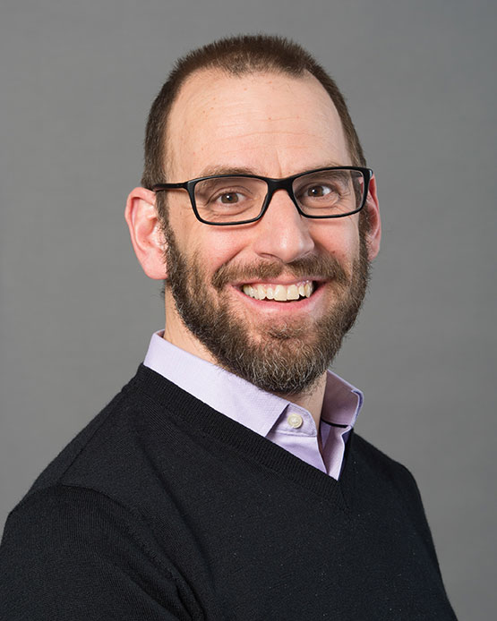

Douglas Manuel

MD, MSc, FRCPC

Co-chair

Senior Scientist; Distinguished University Professor

Ottawa Hospital Research Institute; University of Ottawa

North AmericaPublic health, infectious disease and epidemiology

[ORCID](https://orcid.org/0000-0003-0912-0845)[COI form](https://osf.io/utske/?action=download)

**Read bio**

Doug Manuel is a Distinguished Professor at the University of Ottawa in the Departments of Family Medicine and School of Epidemiology and Public Health. He is a Senior Scientist at The Ottawa Hospital Research Institute, and a Senior Investigator at the Bruyère Health Research Institute. Dr. Manuel holds an M.D. from Dalhousie University, and M.Sc. in Epidemiology and Royal College Speciality in Public Health from the University of Toronto.

He leads the development of the Public Health Environmental Surveillance Open Data Model (PHES ODM) which is used worldwide for wastewater surveillance. He consults for the World Bank for the development of wastewater surveillance in low- and middle-income countries. He formerly led the Coronavirus Variants Rapid Response Network (CoVaRR-Net) Wastewater Research Group.

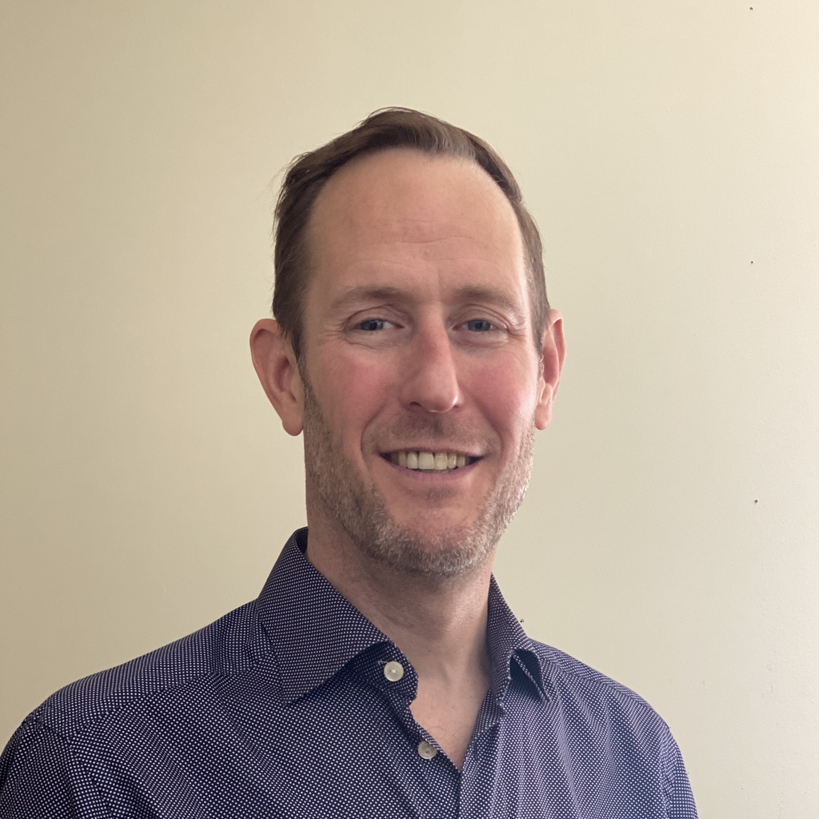

David Buckeridge

MD, MSc, PhD

Co-chair

Professor, School of Population and Global Health

McGill University

North AmericaPublic health, infectious disease and epidemiology

[ORCID](https://orcid.org/0000-0003-1817-5047)[COI form](https://osf.io/uky82/?action=download)

**Read bio**

David Buckeridge is a Professor in the School of Population and Global Health at McGill University in Montreal where he directs the Surveillance Lab, an interdisciplinary group that develops, implements, and evaluates novel computational methods for population health surveillance. He also directs the Anonymized Data Warehouse at the McGill University Health Center, provides informatics advice to the Quebec Institute for Excellence in Health and Social Services, and leads data management and analytics for the COVID-19 Immunity Task Force.

His research and practice focus on the informatics of health surveillance and disease control and he holds a Canada Research Chair (Tier 1) in Health Informatics and Data Science. Dr Buckeridge sits on the Expert Panel advising the Canadian government about health systems during the COVID-19 pandemic. He is also a technical advisor to the World Health Organization Epidemic Intelligence from Open Sources (EIOS) program on the application of artificial intelligence to global infectious disease surveillance. Dr Buckeridge holds an M.D. from Queen’s University, a M.Sc. in Epidemiology from the University of Toronto, and a Ph.D. in Biomedical Informatics from Stanford University.

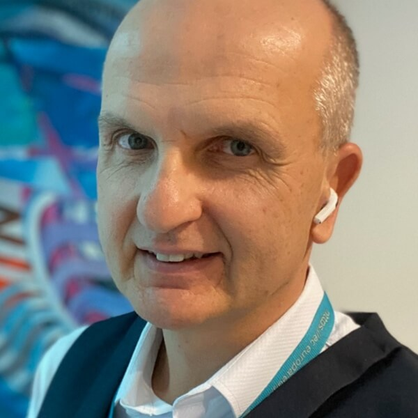

Bernd Manfred Gawlik

PhD

Portfolio Leader, Water Quality

European Commission Joint Research Centre

Europe and Central AsiaEnvironmental and physical sciences

[ORCID](https://orcid.org/0000-0002-4406-5362)

**Read bio**

Dr. Bernd Manfred Gawlik is Portfolio Leader at the European Commission’s Joint Research Centre, where he coordinates the activities on water quality. He holds an Engineering degree from the French Higher Institute for Industrial Chemistry and a Ph.D. on Natural Sciences from Technical University of Munich. In the past two decades he has been working on several major European environmental directives involving chemical monitoring and pollutants of emerging concern. He is closely involved in the Common Implementation Strategy of the Water Framework Directive, umbrella under which he co-designed the Water Reuse Regulation. During the pandemic, Bernd united the European actors and stakeholder on wastewater-based epidemiology and ensured the speedy translation from knowledge to action as expressed by the respective Recommendation of the European Commission. Bernd is the author/co-author of more than 100 scientific papers, books and reports of the European Commission and promotes novel approaches on water diplomacy.

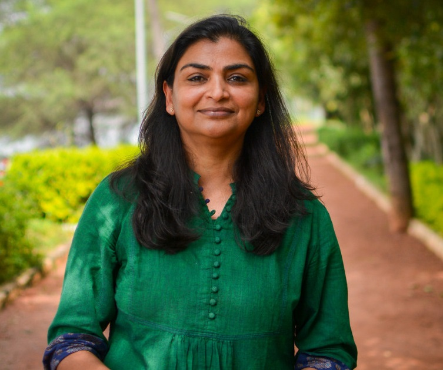

Farah Ishtiaq

PhD

Lead, Disease Ecology and Environmental Surveillance

Tata Institute for Genetics and Society

South AsiaEnvironmental and physical sciencesPublic health, infectious disease and epidemiology

[COI form](https://osf.io/f5bme/?action=download)

**Read bio**

Farah is an evolutionary ecologist interested in the ecology and evolution of emerging infectious diseases. Their experience in research and conservation is based on 25 years of involvement in various projects around the world. They have been a national coordinator of Important Bird Areas programme (India) and conducted research on critically endangered and threatened birds, impact of introduced birds and their parasites (avian malaria in Hawaii) at Smithsonian Institution as a postdoc and vector communities on remote pacific islands (New Caledonia, Vanuatu and nearby islands) as Marie Curie Fellow at University of Oxford, and ecology of avian influenza SE Asia (Mongolia) with Wildlife Conservation Society. As Wellcome Trust/DBT India Alliance fellow, their long-term research explored the epidemiology of avian malaria and spread of disease in high altitude malaria-free zones in the face of climate-change. In their current role at Tata Institute for Genetics and Society, they lead the disease ecology and environmental surveillance – mainly focusing on ecology and population genomics of key mosquito species involved in malaria and dengue transmission in India. They also lead environmental surveillance of SARS-CoV-2 as an early warning system for Bengaluru city and expanding it to other pathogens.

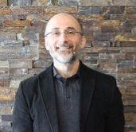

David Moher

MSc, PhD

Senior Scientist, Clinical Epidemiology Program

Ottawa Hospital Research Institute

North AmericaCommunication, knowledge translation and exchangePublic health, infectious disease and epidemiology

[ORCID](https://orcid.org/0000-0003-2434-4206)[COI form](https://osf.io/ws5u7/?action=download)

**Read bio**

Dr. David Moher is a senior scientist, Clinical Epidemiology Program, Ottawa Hospital Research Institute, where he directs the Centre for Journalology. Dr. Moher is also a full Professor, School of Epidemiology and Public Health, Faculty of Medicine, University of Ottawa. Dr. Moher received an MSc in epidemiology and PhD in clinical epidemiology and biostatistics. Dr. Moher is a fellow of the Royal Society of Canada, and Canadian Academy of Health Sciences. Dr. Moher works in knowledge synthesis; predatory journals; reporting guidelines; and open science.

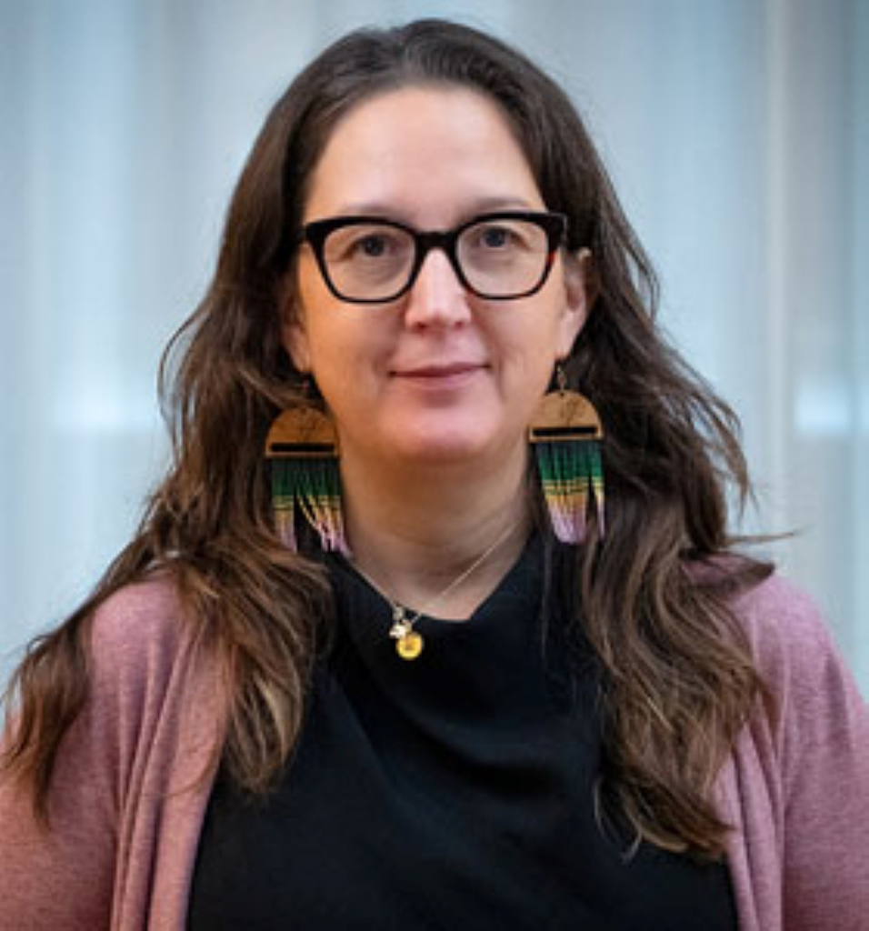

Sarah Funnell

MD, CCFP, MSc, FRCPC

Associate Dean and Chair of Indigenous Health

Queen’s Health Sciences, Queen’s University

North AmericaSocial sciencesPublic health, infectious disease and epidemiology

[COI form](https://osf.io/9fxdh/?action=download)

**Read bio**

Dr. Sarah Funnell is a First Nations family physician, public health specialist, and clinician scientist. Her background is mixed Algonquin and Tuscarora ancestry, and she grew up among the Mississaugas of Alderville First Nation and is a current band member of Kitigan Zibi First Nation. Her Algonquin name, Minwanimad, means pleasant breeze and was given to her by her great Auntie who saw her gift of leadership.

Dr. Sarah Funnell is the Associate Dean and Chair of Indigenous Health at Queen’s Health Sciences (QHS) and Assistant Professor, Department of Family Medicine. In these roles she leads efforts to incorporate Indigenous health and cultural perspectives into health education, administration, research, and clinical practice.

Dr. Funnell has a passion for leadership and good governance. She is an executive and founding member of the National Consortium for Indigenous Medical Education and a Senior Editor for the Canadian Journal of Public Health. Throughout her career, she has been an active voice and advocate to improve Indigenous health and curriculum through her volunteer work with College of Family Physicians of Canada (CFPC), Royal College, Medical Council of Canada (MCC), and the Association of Faculties of Medicine of Canada (AFMC).

Her research focus includes Indigenous population health, Indigenous data governance, and the impact of COVID-19 on the healthcare of Indigenous older adults. She is an award-winning educator and prolific speaker on topics related to Indigenous health, health equity, public health, and primary care.

[figure not shown]

Matthew Wade

PhD

Senior Environmental Science Advisor

UK Health Security Agency

Europe and Central AsiaMathematical sciencesEnvironmental and physical sciences

[ORCID](https://orcid.org/0000-0001-9824-7121)[COI form](https://osf.io/cg8pr/?action=download)

**Read bio**

Dr. Matthew Wade is a Senior Environmental Science Advisor in the Data Analytics & Surveillance Group at the UK Health Security Agency. He helped deliver the English Wastewater Monitoring Programme for COVID-19 from October 2020 to March 2022. Prior to joining the UK Civil Service, he held a Marie Sklodowska-Curie Individual Fellowship, spending two years at McMaster University in Canada where he researched the mathematics and modelling of engineered biological systems, with special interest in the dynamics of microbial ecology. During his time in Canada, he spent 6 months as a visiting fellow at The Fields Institute in Toronto, participating in the “Emergent Challenges in Mathematical Biology” major thematic program. He has spent over 20 years working at the interface of mathematics, engineering and biology within academia and industry, within both research and operational delivery of complex systems in the agriculture, water, energy, and pharmaceutical sectors. He has a Bachelor of Engineering and Master of Science from Newcastle University, and a PhD from Strathclyde University and is a member of the International Water Association and Water Environmental Foundation. He is currently an editor for the Journal of Water & Health, Water Science & Technology, Frontiers in Microbiology, and Bioengineering journals.

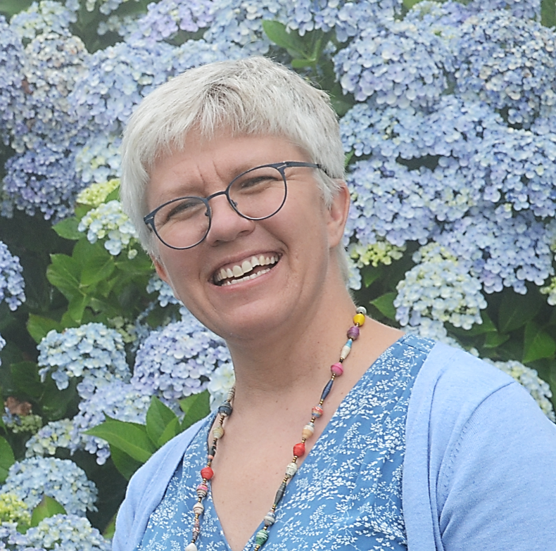

Kerrigan McCarthy

PhD

Specialist Pathologist (Microbiology)

National Institute for Communicable Diseases (NICD)

Sub-Saharan AfricaEnvironmental and physical sciencesPublic health, infectious disease and epidemiology

[ORCID](https://orcid.org/0000-0001-8958-9795)[COI form](https://osf.io/3hyr8/?action=download)

**Read bio**

Dr. Kerrigan McCarthy is a specialist pathologist in the discipline of microbiology who specialises in the laboratory diagnosis of infectious disease. She has a PhD in Public Health from Wits. She has worked at the NICD in quality assurance and mycology, and for a number of NGOs doing health system strengthening in the area of TB/HIV integration. She co-ordinated the national evaluation of the GeneXpert technology for the diagnosis of tuberculosis. Since working at the NICD she has supported national and provincial responses to outbreaks, including listeria and SARS-CoV-2.

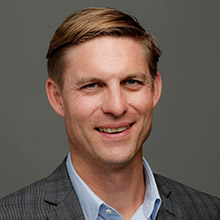

Jeremy Veillard

PhD

Lead Health Specialist, Latin America and Caribbean Region

World Bank

Latin America and CaribbeanSocial sciencesPublic health, infectious disease and epidemiology

[COI form](https://osf.io/k3d2s/?action=download)

**Read bio**

Jeremy Veillard is a Lead Health Specialist in the Latin America and Caribbean Region, for Health, Nutrition and Population, at the World Bank. Jeremy is a former health care executive in Canada and France, with deep expertise in quality of care, service delivery performance and health systems research and analytics. Jeremy has a PhD in public health (health systems research) from the University of Amsterdam, The Netherlands and a masters in hospital administration from the Ecole des Hautes Etudes en Santé Publique, France.

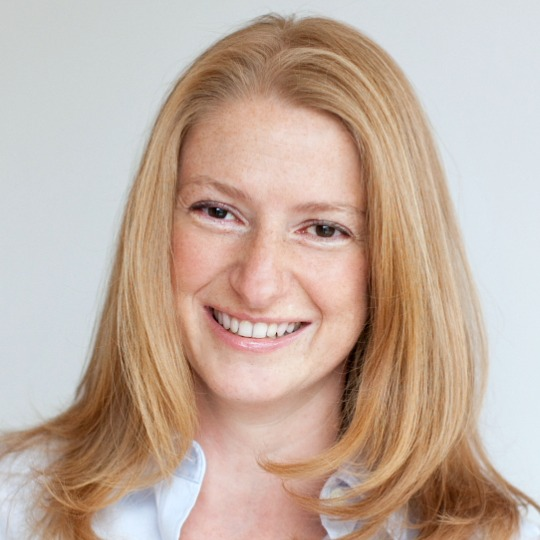

Beate Sander

RN, MBA, MEcDev, PhD

Canada Research Chair in Economics of Infectious Diseases; Senior Scientist

University Health Network; University of Toronto

North AmericaMathematical sciencesPublic health, infectious disease and epidemiology

[ORCID](https://orcid.org/0000-0003-2128-9133)[COI form](https://osf.io/vz72q/?action=download)

**Read bio**

Beate Sander, RN MBA MEcDev PhD, holds a Canada Research Chair in Economics of Infectious Diseases, is a Senior Scientist at the Toronto Health Economics and Technology Assessment (THETA) collaborative at the Toronto General Hospital Research Institute, University Health Network (UHN), and Professor at the Institute of Health Policy, Management and Evaluation (IHPME), University of Toronto.

Dr. Sander is an internationally recognized leader in infectious disease economics with extensive expertise in health economics and simulation modeling. Her research focus is on assessing infectious disease interventions using simulation modeling and on estimating the burden of infectious diseases using population-based data. Dr. Sander has received several awards for research excellence.

Dr. Sander is an expert to national and international advisory bodies, including Canada’s National Advisory Committee on Immunization (NACI), where she chairs the Economics Task Group and co-chairs the Economic Guidelines Task Group – a group tasked with developing national guidelines for the economic evaluation of vaccines, which will set the standard for conducting economic evaluations for vaccines in Canada. Dr. Sander co-chaired the Ontario COVID-19 Modeling Consensus Table from March 2020 to March 2022 and was a member of Ontario’s Science Advisory Table, leading timely COVID-19 evidence generation and knowledge mobilization. Dr. Sander is a member of several Federal expert advisory committees and President of the international Society for Medical Decision Making.

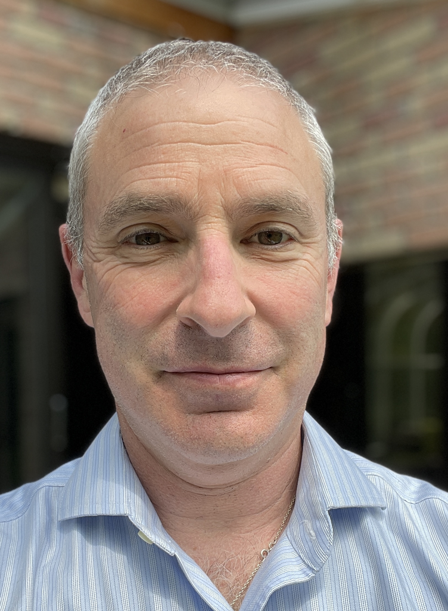

Yoni Freedhoff

MD

Associate Professor of Family Medicine

University of Ottawa

North AmericaCommunication, knowledge translation and exchange

[ORCID](https://orcid.org/0000-0001-9391-3455)[COI form](https://osf.io/d8bcm/?action=download)

**Read bio**

Yoni Freedhoff is an Associate Professor of Family Medicine at the University of Ottawa and the medical director of the Bariatric Medical Institute as well as Constant Health. Outside patient care he has dedicated much of his professional career to science communication and public health advocacy which has led him to author a number one national bestselling book, have bylines in the New York Times, TIME, Macleans and more, author an ongoing Medscape column, serve as a regular expert for both national and international media, and on multiple occasions deliver invited testimony to Canada’s Senate and House of Commons.

## Study working group

The PHES-EF study working group, based at the Ottawa Hospital Research Institute, manages day-to-day research activities, coordinates the executive group, facilitates engagement with actors and end-users, and supports the implementation of all project components. The team moves the project forward through research coordination, knowledge synthesis, consultation with actors and end-users, and framework development.

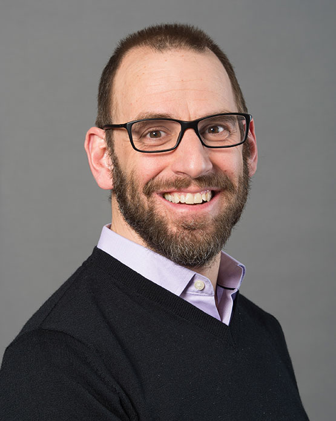

Douglas Manuel

MD, MSc, FRCPC

Principal investigator

Senior Scientist; Distinguished University Professor

Ottawa Hospital Research Institute; University of Ottawa

North AmericaPublic health, infectious disease and epidemiology

[ORCID](https://orcid.org/0000-0003-0912-0845)[COI form](https://osf.io/utske/?action=download)

**Read bio**

Doug Manuel is a Distinguished Professor at the University of Ottawa in the Departments of Family Medicine and School of Epidemiology and Public Health. He is a Senior Scientist at The Ottawa Hospital Research Institute, and a Senior Investigator at the Bruyère Health Research Institute. Dr. Manuel holds an M.D. from Dalhousie University, and M.Sc. in Epidemiology and Royal College Speciality in Public Health from the University of Toronto.

He leads the development of the Public Health Environmental Surveillance Open Data Model (PHES ODM) which is used worldwide for wastewater surveillance. He consults for the World Bank for the development of wastewater surveillance in low- and middle-income countries. He formerly led the Coronavirus Variants Rapid Response Network (CoVaRR-Net) Wastewater Research Group.

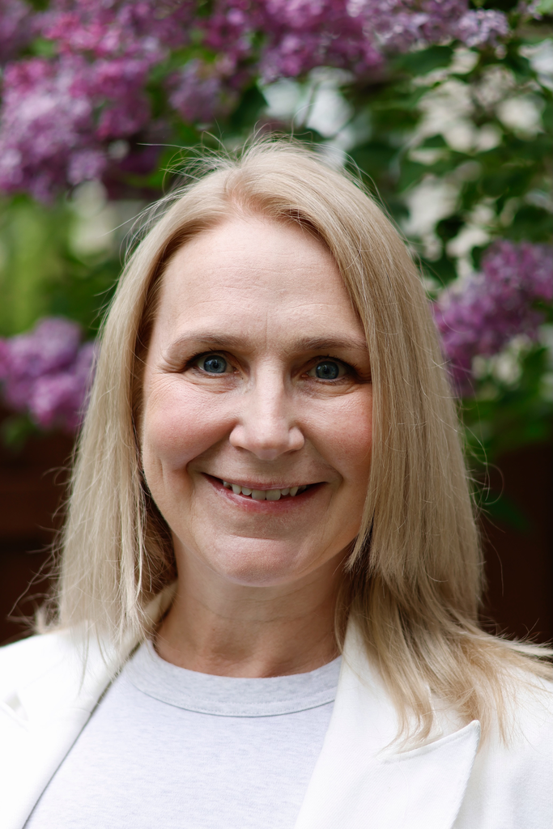

Carol Bennett

MSc

Senior Clinical Research Associate

Ottawa Hospital Research Institute

North America

[ORCID](https://orcid.org/0000-0002-3033-9860)

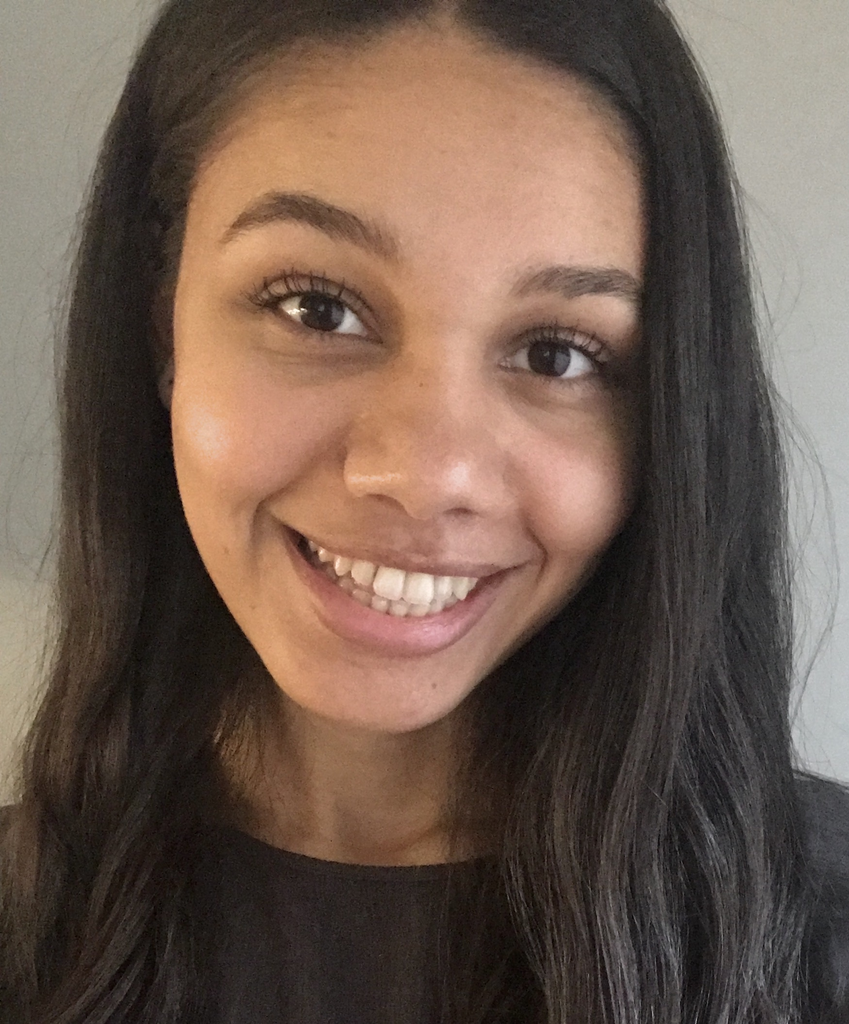

Emma Brown

Clinical Research Assistant

Ottawa Hospital Research Institute

North America

[ORCID](https://orcid.org/0000-0002-0869-9907)

## Past members

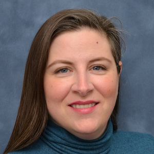

Amy Kirby

PhD, MPH

Program Lead, National Wastewater Surveillance System

Centers for Disease Control and Prevention (CDC)

North AmericaEnvironmental and physical sciencesPublic health, infectious disease and epidemiology

Executive group member, November 2022 to November 2025

**Read bio**

Dr. Amy Kirby is an Environmental Microbiologist in the Waterborne Disease Prevention Branch and the Program Lead for the National Wastewater Surveillance System (NWSS) at the Centers for Disease Control and Prevention (CDC). She has a Bachelor of Science in Agriculture from the University of Georgia, a PhD in Microbiology from the University of Buffalo, SUNY, and a Master of Public Health in Epidemiology from Emory University. At CDC, Dr. Kirby is interested in leveraging environmental microbiology methods to measure pathogens, antibiotic resistance genes, and other health indicators in natural and man-made water systems.

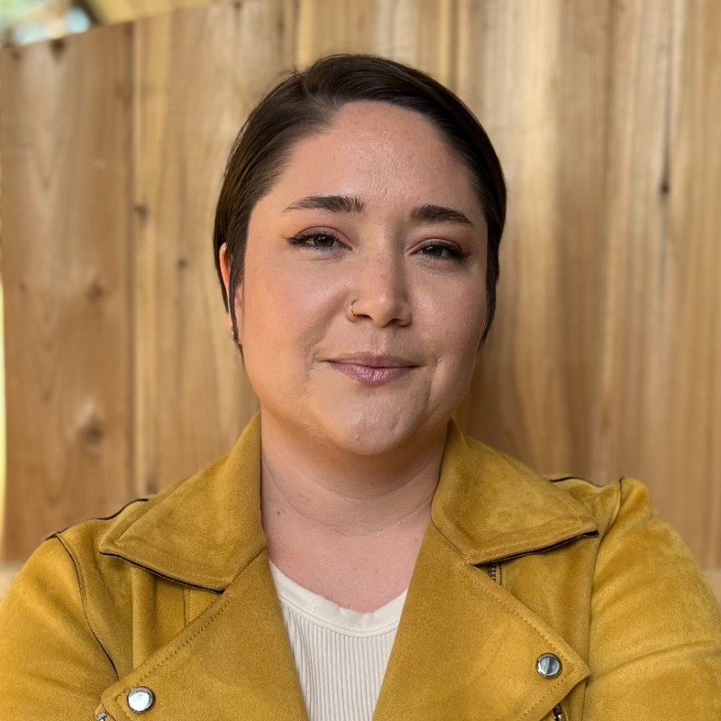

Mary Jessome

Lead Researcher, #BeadAndThrive social media engagement

CIEDAR; Department of Sociology, University of British Columbia

North AmericaSocial sciences

Executive group member, November 2022 to January 2024

**Read bio**

Mary is the lead researcher for CIEDAR’s #BeadAndThrive social media engagement. They joined CIEDAR after working as a research and data analytics officer for the Department of Canadian Heritage, where their focus on equity and inclusion helped inform the governance of Canada’s diverse populations (i.e., 2SLGBTQ+, Persons Living with Disabilities, and Indigenous Peoples). Mary is also a PhD student in the Department of Sociology at the University of British Columbia. Their research focuses on assortative mating patterns among gender diverse (i.e., transgender and non-binary) Canadians and how these patterns reproduce socio-economic inequalities.

## Acknowledgements

We thank Peter Farrell (Research Librarian, University of Ottawa) for developing the associated scoping review search strategies for this study.